# final

Laith Alayassa

6/28/2021

I have lived in Armenia for the past two years (2018-2020) before coming back here to Palestine, there, I have finished my IB diploma and lived in an international school at times, and finished the two years living with locals. When I first came to Armenia, I did not feel it was very different from my home in Palestine, they were both countries with poor populations, however, there was a noticeable difference in the economic and social situation in Armenia after those two years have passed, and I want to investigate.

In 2019, Armenians around me were laughing at the fact that their country was marked as the angriest in the world in a Gallup survey with %45 of their population expressing feeling a lot of anger in the previous day (McCarthy). This got me thinking about the well-being and the happiness of the population since I imagine that a psychologically distressed population would have a hard time developing its economy.

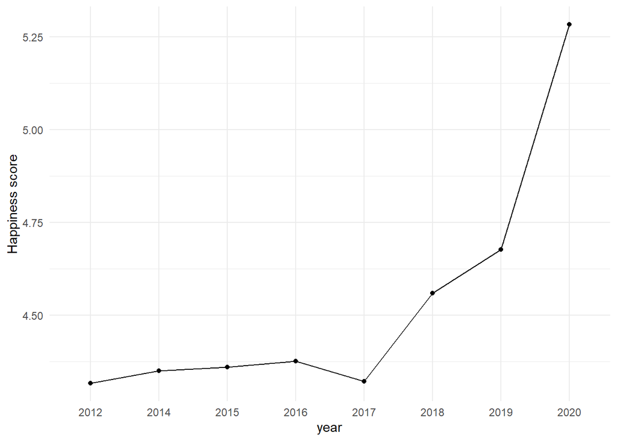

We can see that during the past few years starting from 2017, there has been a sharp increase in the happiness index in the country compared with the prior years. This increase of nearly 1 point in happiness scale took Armenia from being the 128th happiest country to the 86th happiest country in the world in an extraordinarly short time(“World Happiness Index - Knoema.Com”).

These conflicting messages suggest that while Armenians might be the angriest people on the planet -however extraordinary generous- they are making rapid progress in terns if happiness.

I will try to explore the reasons for this increase in happiness and overall well-being of the country that I have witnessed in such a short time and that the data suggests. I will use the word “satisfaction” to indicate the results from the happiness scale and will start analyzing with 2 Hypothesis: Increased satisfaction due to economic growth, increased satisfaction after the 2018 revolution.

To explore economic growth I will start by looking at GDP (constant 2010 US$):

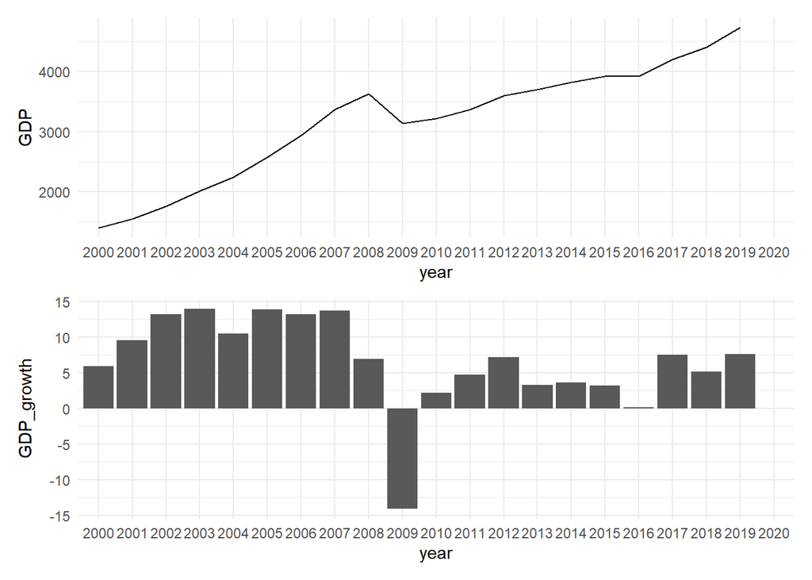

One element that is greatly contributing to the economy of Armenia is tourism due to its remarkable nature and the fact that most Armenians speak Russian, making it a popular destination for poeple from Caucasis and Russian-speaking nations.

[figure not shown]

```
## [1] TRUE
```

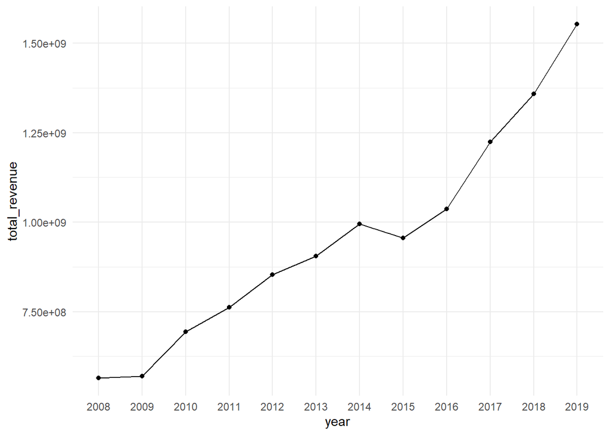

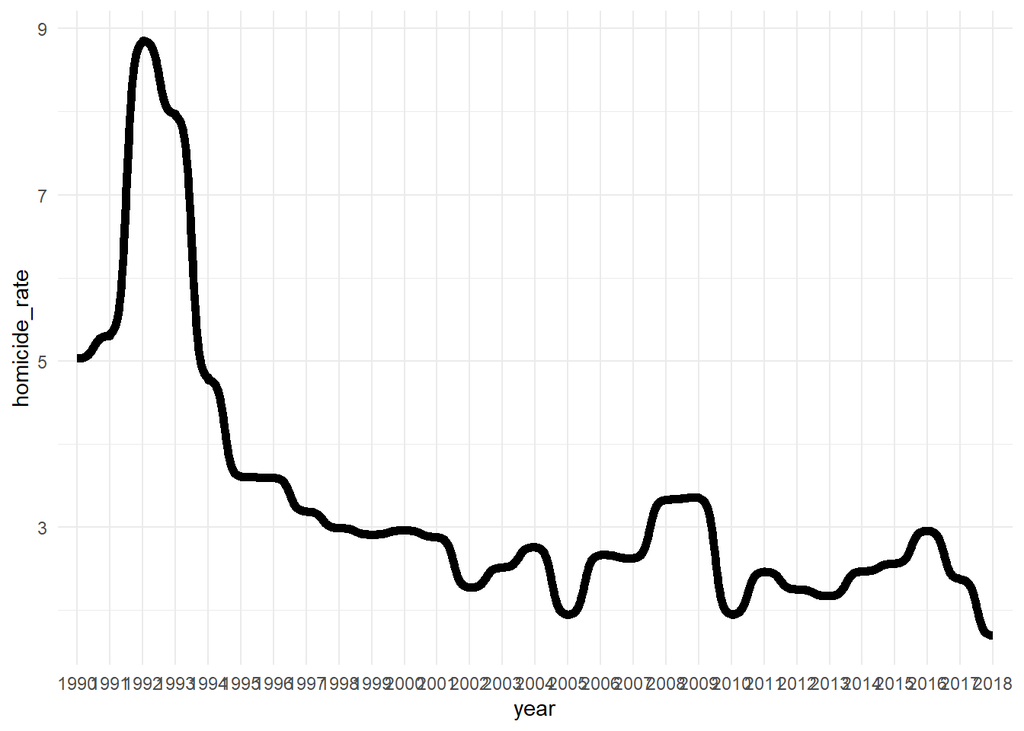